# Proyecto - P2

**Tema delimitado:** Impacto de la conexión a Internet en el rendimiento académico de los estudiantes UTEC.

# **Introducción**

## Relevancia

La relevancia de nuestro tema recae en el proceso de transición que estamos pasando. El mundo entero ha superado casi al completo la etapa de educación a distancia y poco a poco se están volviendo a implementar los sistemas de aprendizaje presenciales, luego de 2 años de ser sustituídos. Con la ayuda de este estudio, nuestra intención es de evaluar qué tan eficaz y cuán buena fue esta etapa de modalidad virtual en la comunidad de UTEC. De esta manera podremos llegar a analizar sus puntos fuertes y débiles para así aprender de estos y poder implementarlos en modalidades virtuales o híbridas en un futuro.

El estudio realizado está enfocado principalmente en el criterio de la calidad de internet de los estudiantes en la comunidad. Con esta información además de evaluar la eficiencia de la modalidad virtual propuesta por la universidad, sino que también tendremos una noción de las capacidades y calidad del internet del estudiante en la comunidad. Así, se podrán evaluar de manera más eficaz la viabilidad de las evaluaciones que requieran de esta modalidad por si la universidad decide utilizarlas, pudiendo de esta manera ayudar a los alumnos que no cuenten con una conexión muy estable. Por último, con el estudio se podra registrar una retroalimentación acerca de las experiencias de los alumnos de UTEC a través del periodo de virutalidad con respecto a su calidad de internet y cómo repercutió esto en su desempeño académico.

## Planificación

La planificación de nuestro proyecto consistió en dividir el trabajo en varias tareas y asignar estas a los integrantes del grupo usando un diagrama de Gantt; en nuestro caso, casi todas las tareas las hicimos con la totalidad del grupo. Además, utilizamos la página web When2meet para poder establecer un horario accesible para todo el grupo asignando cada uno las horas en las que está disponible para encontrar el mejor momento para todosy poder reunirnos en zoom, y así poder cumplir el orden de tareas establecidos en el diagrama de Gantt.

# **Datos**

## Proceso de recolección de datos

Los datos fueron obtenidos mediante una encuesta de “Google Forms”. La misma, fue distribuida a través de diversos medios, entre ellos, plataformas como Gmail y redes sociales como Telegram y Whatsapp. Asimismo, se tomó la decisión de recorrer el campus presencialmente e ir encuestando a las personas que se encontraran en nuestro camino. La recolección fue llevada a cabo de esta manera para así poder asegurar al menos la diversidad de unidades muestrales entorno a tres variables, Ciclo, Carrera y Edad. Para las mismas se utilizó Gmail, redes sociales y el recorrido del campus respectivamente. Por otro lado, intentamos asegurar la diversidad de la variable ubicación/residencia únicamente por conveniencia, consultando a compañeros y amistades que sabíamos que vivían fuera de Lima provincia.

## Población, Muestra y Muestreo

**Población**: Comunidad Estudiantil UTEC

**Unidad Muestral**: Todo alumno regular perteneciente a la comunidad UTEC

**Muestreo**: Muestreo por Conveniencia Dada la complejidad de los tipos de muestreo probabilístico y la falta de experiencia al momento de muestrear por nuestra parte, optamos por realizar un Muestreo por Conveniencia. En él, compartiríamos nuestra encuesta con aquellas personas cercanas a nuestro círculo y con aquellas que estuvieran interesadas en apoyar nuestra investigación.

## Variables

Mediante el comando str(), encontramos que RStudio define incorrectamente 3 variables.

| Variables | Interpretación RStudio | Interpretación correcta | Restricciones |
| --- | --- | --- | --- |
| Ingreso | Categórica | Categórica Ordinal | Formato 20xx-x |
| Peor_Conectividad | Categórica | Categórica Nominal | 4 Opciones |
| Actuales_Cursos | Numérica | Numérica Discreta | Números enteros entre 0 y 10 |
| Convivientes | Categórica | Numérica Discreta | Números enteros entre 0 y 10 |
| Distrito | Categórica | Categórica Nominal | - |
| Residencia | Categórica | Categórica Nominal | - |
| Tipo_Conexion | Categórica | Categórica Nominal | - |
| Opinion | Numérica | Numérica Discreta | Números enteros entre 0 y 6 |
| Equipos_Conectados | Categórica | Numérica Discreta | Números enteros entre 1 y 20 |
| Estudio_Horas | Numérica | Numérica Discreta | Números enteros entre 0 y 16 |
| Ocio_Horas | Numérica | Numérica Discreta | Números enteros entre 0 y 12 |
| Inasistencia | Categórica | Categórica Nomoinal | Respuestas binarias de si y no |
| Pruebas_Perdidas | Categórica | Numérica Discreta | Números enteros entre 0 y 10 |
| Alternativa | Categórica | Categórica Nominal | Respuestas binarias de si y no |
| Operador | Categórica | Categórica Nominal | - |
| Ping | Numérica | Numérica Discreta | Números enteros positivos |
| Download | Numérica | Numérica Continua | Números positivos con 2 decimales |
| Upload | Numérica | Numérica Continua | Números positivos con 2 decimales |
| Menor_Ciclo | Numérica | Numérica Discreta | Números enteros entre 0 y 10 |
| Pasados_Cursos | Numérica | Numérica Discreta | Números enteros entre 0 y 10 |
| Pasados_A_Cursos | Numérica | Numérica Discreta | Números enteros entre 0 y 10 |
| Promedio | Numérica | Numérica Continua | Números positivos con 2 decimales entre 0 y 20 |

## Limpieza de base de datos

**1. Corregimos el nombre y categoría de las variables:** - Al transformar la encuesta de Google forms a un archivo .csv las respuestas se asignan automáticamente a variables con nombre de la pregunta completa, por lo que cambiamos ese criterio a nombres más descriptivos, y fáciles de identificar y escribir al momento de trabajar. Además, en ciertas preguntas se debían corregir las respuestas que tenían forma de oración a numérica para poder trabajar de forma adecuada.

**2. Eliminar observación 1:** - Al momento de armar la encuesta, llenamos la encuesta en búsqueda de algún error para luego poder difundirla a la comunidad de estudiantes. Por esta razón al inicio de la base de datos existe una observación extra que se debe eliminar.

**3. Eliminar primera variable:** - La encuesta de Google Forms guarda el momento en el que la persona llenó la encuesta. Esta información no es de utilidad para el estudio por lo que eliminamos la variable, y así tener un Data Frame solo con lo que necesitamos.

**4. Crear DF con data limpia:** - Luego de realizar todos los cambios a la base de datos inicial, la guardamos en un nuevo archivo .csv para poder trabajar con el y no tener que volver pasar por el proceso de limpieza para trabajar con el Data Frame.

**5. Cargar data limpia con variables correctamente interpretadas:** - Asignamos el tipo de variable correcto a cada columna del nuevo Data Frame limpio para poder trabajar y que RStudio nos permita utilizar las funciones correspondientes en cada una.

# Análisis Descriptivo

## Figuras de mérito

### Categórica Ordinal

**1. Ingreso:** Las altas frecuencias de una determinada categoría se debe al sesgo ocasionado por realizar un muestreo por conveniencia

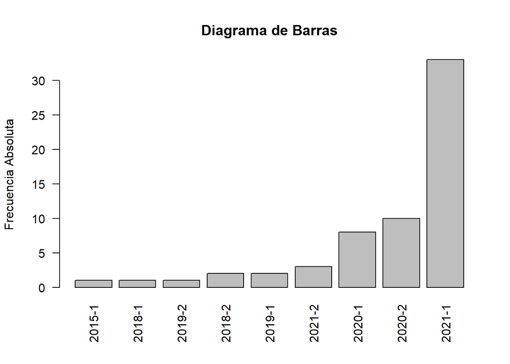

### Categórica Nominal

**2. Peor_Conectividad**

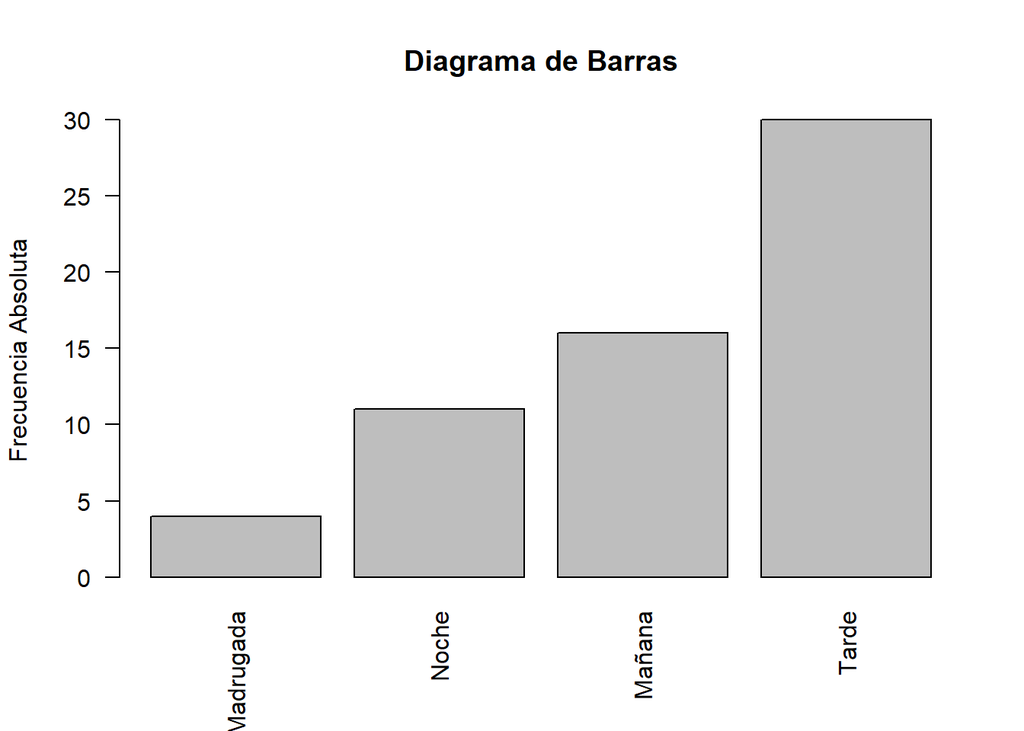

**3. Tipo_Conexión**

Optamos por no graficar un Diagrama de Barras ya que la variable Tipo_Conexion al tener solo dos categorías se explica de forma adecuada utilizando un descriptor tabular como lo es una tabla de frecuencias absolutas

| Tipo_Conexion | n |
| --- | --- |
| Red wifi | 47 |
| Cable Ethernet | 14 |

**4. Alternativa**

Utilizamos el comando “count” de la librería dplyr y el comando “table” de la librería por defecto RBase para calculas las frecuencias de la variable

| Alternativa | n |
| --- | --- |
| Sí | 49 |
| No | 12 |

```
##
## No Sí
## 12 49
```

### Numérica Discreta

**5. Ping**

Vemos datos claramente atípicos que nos obligan a desconfiar de la media aritmética, dado que la misma es un descriptor no robusto.

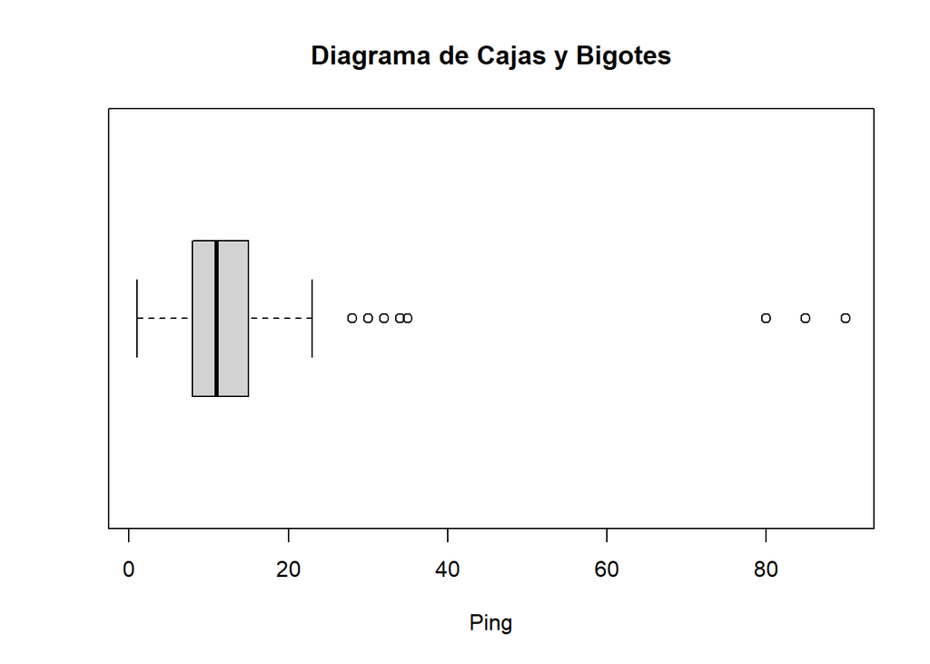

Debido a que es complicado identificar los valores e inviable identificar la cantidad de los datos atípicos en la gráfica, asignamos el boxplot a una nueva variable “boxplot_ping” para luego llamar a la función “summary” y que nos retorne el resultado “out”, el cual, aduce a la cantidad de datos outlier igual a 9.

Asimismo, vemos que al llamar a la variable “boxplot_ping” nos retorna una sección “$out”, la cual, detalla los valores de esos 9 datos atípicos y al ver que la magnitud de un valor atípico se repite (28) comprobamos nuestra idea de ser inviable identificar la cantidad de outliers con solo ver la gráfica.

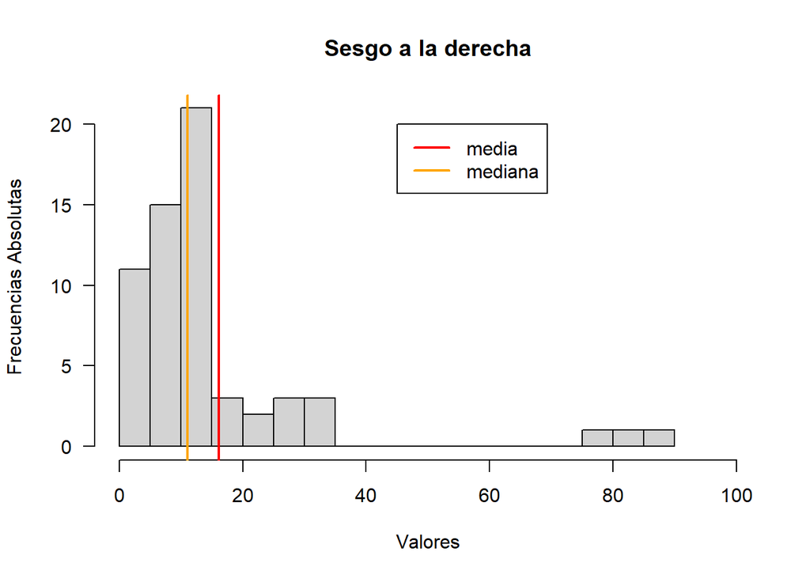

**6. Pruebas_Perdidas**

Resulta interesante mencionar por qué el bigote de la izquierda no ha sido graficado. Esto se debe a que el primer valor coincide con el primer cuartil. En otras palabras, el valor marcado por el extremo izquierdo de la caja se repite como mínimo un 25% de veces con respecto al total. Pensar que el bigote izquierdo no existe es una conclusión errada. El comando boxplot asigna por defecto una magnitud determinada al largo de cada bigote, esto se configura con el parámetro “range”, sin embargo, si no hay presencia de outliers en esa zona, el bigote simplemente no se grafica

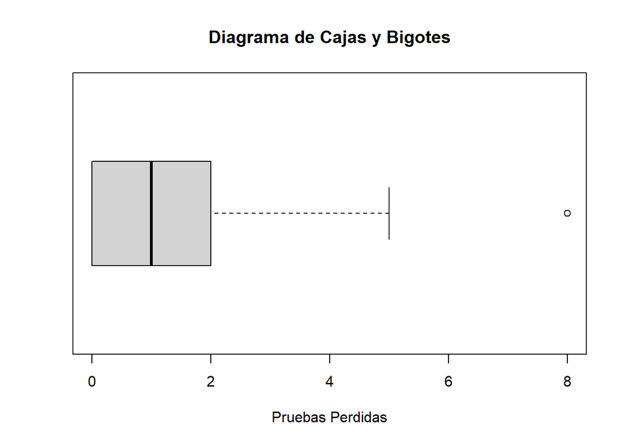

Al realizar una tabla de frecuencias absolutas vemos que la moda categórica es el 0. Al ver esto, uno podría sacar conclusiones alentadoras para los estudiantes de la UTEC; sin embargo, que el valor que más se repita sea el 0 no significa que todos se hayan salvado de perderse algún examen por una mala conectividad, hay que evaluar valores relativos. Para esto, diseñamos una nueva columna con las frecuencias relativas de cada categoría. Concluimos que, a pesar que el 0 es la moda, abarca solo un 34% de la muestra. Dicho de otro modo, hay un 66% de encuestados que como mínimo han perdido una prueba debido a una mala conectividad

| Pruebas_Perdidas | n | frecuencia_relativa |
| --- | --- | --- |
| 0 | 21 | 0.34 |
| 2 | 18 | 0.30 |
| 1 | 12 | 0.20 |
| 4 | 4 | 0.07 |
| 5 | 3 | 0.05 |
| 3 | 2 | 0.03 |
| 8 | 1 | 0.02 |

### Numérica Continua

**7. Download**

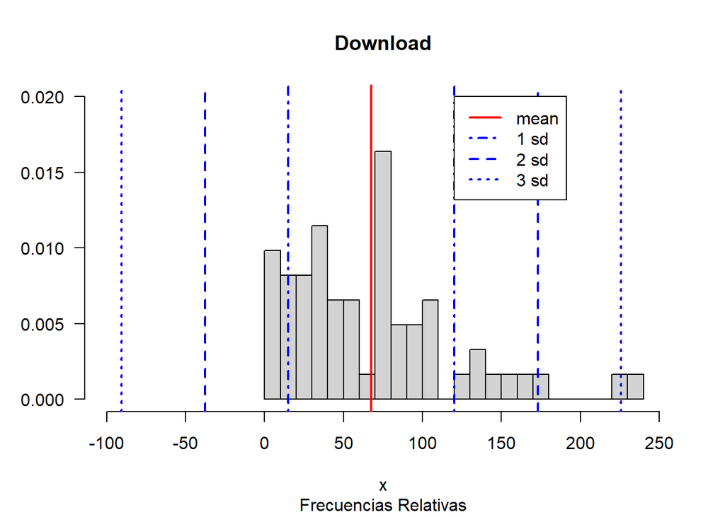

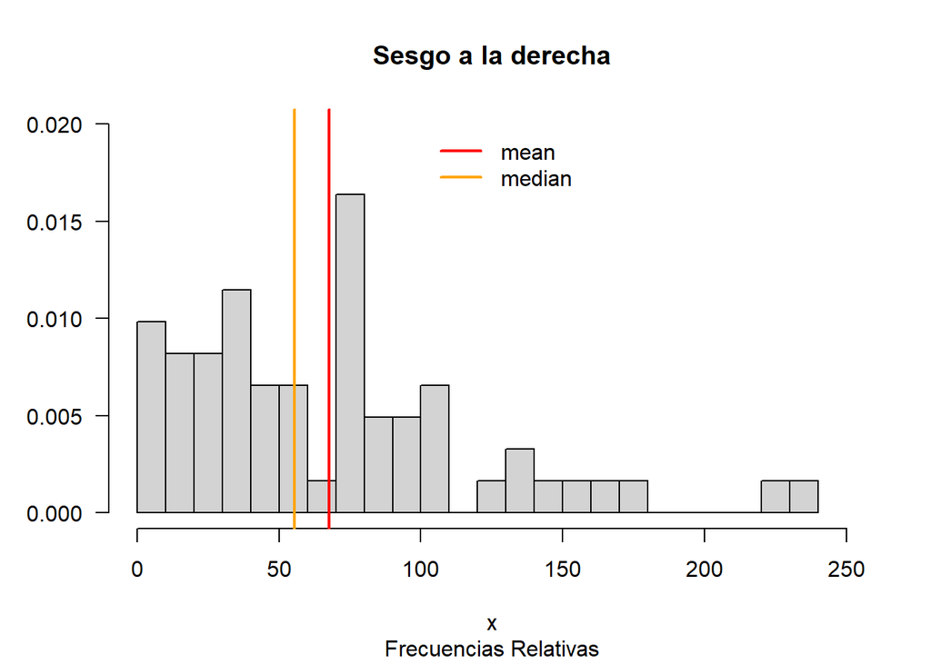

**8. Promedio**

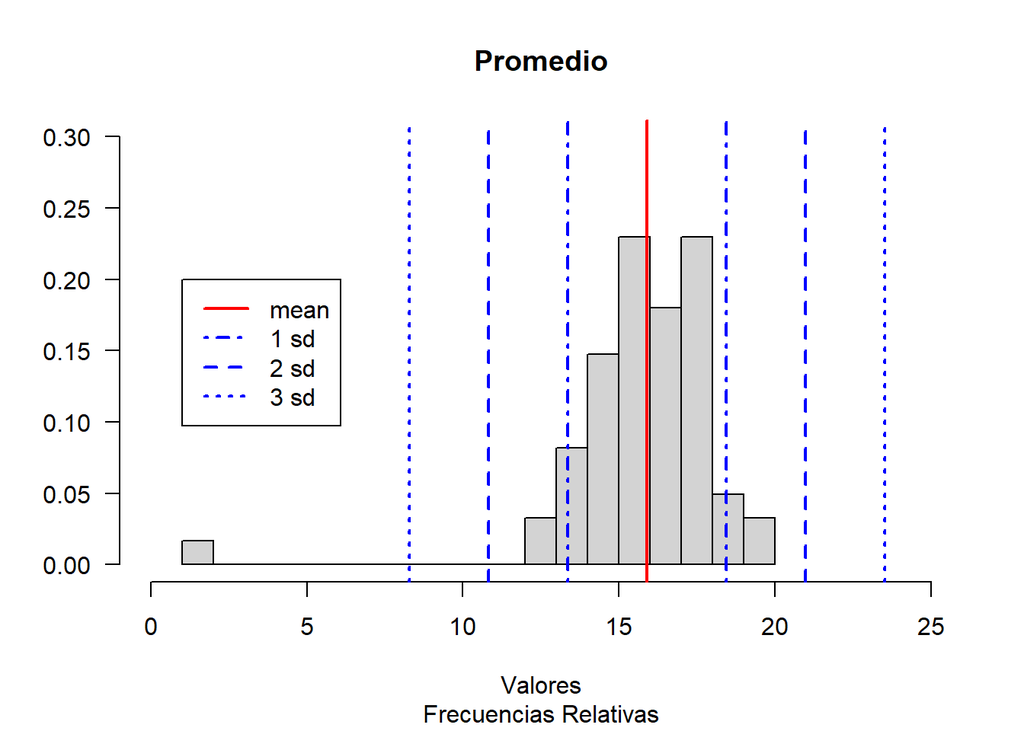

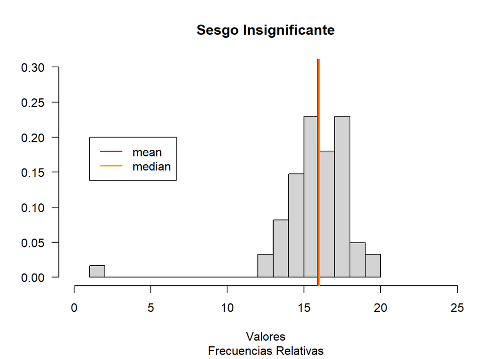

## Análisis Bivariado y Multivariado

**1. “Calidad de Internet” - Promedio**

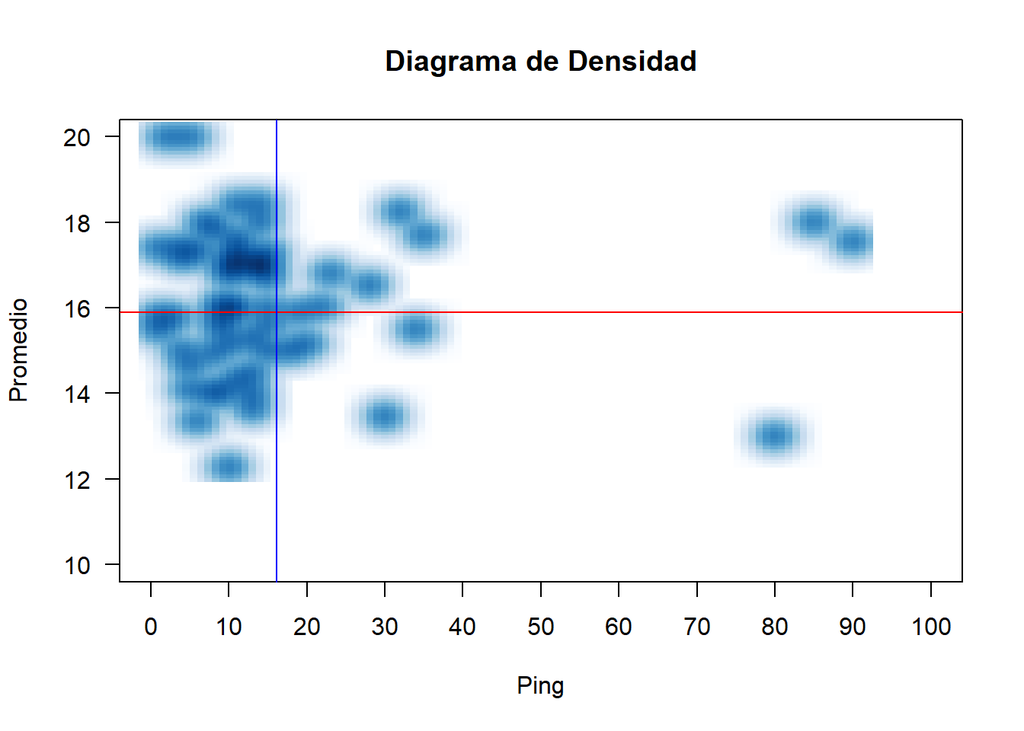

**2. Download - Upload**

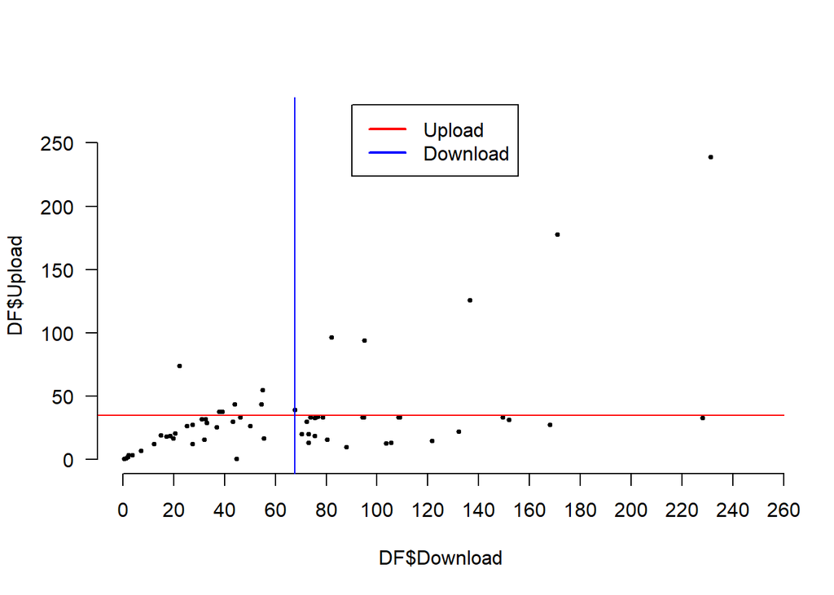

**3. “Calidad de Internet” - Operador**

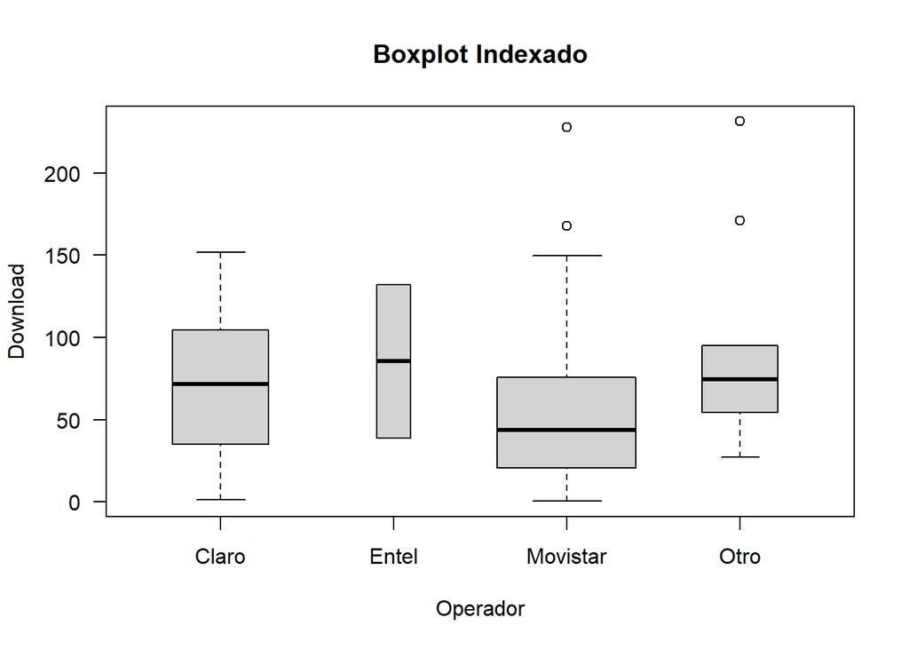

**4. Alternativa - Inasistencia**

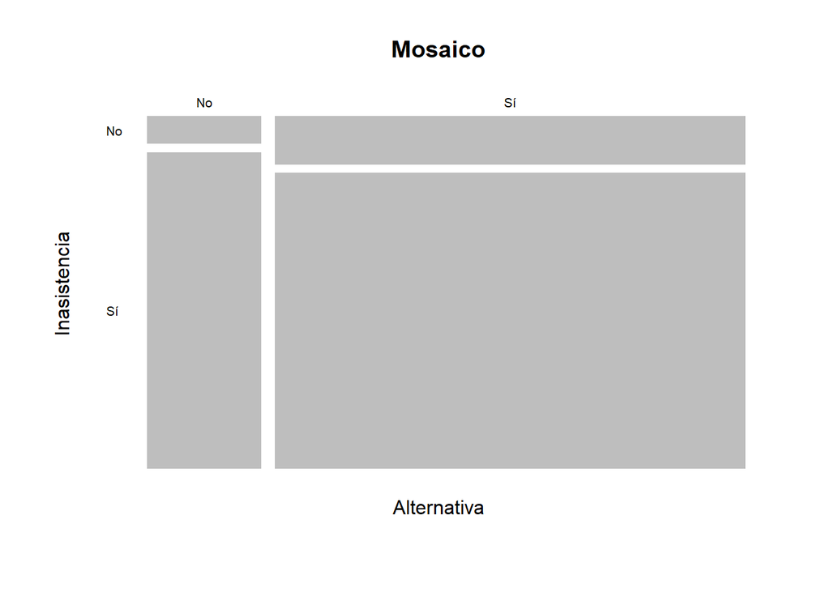

**5. “Calidad de Internet” - Promedio - Tipo_Conexión**

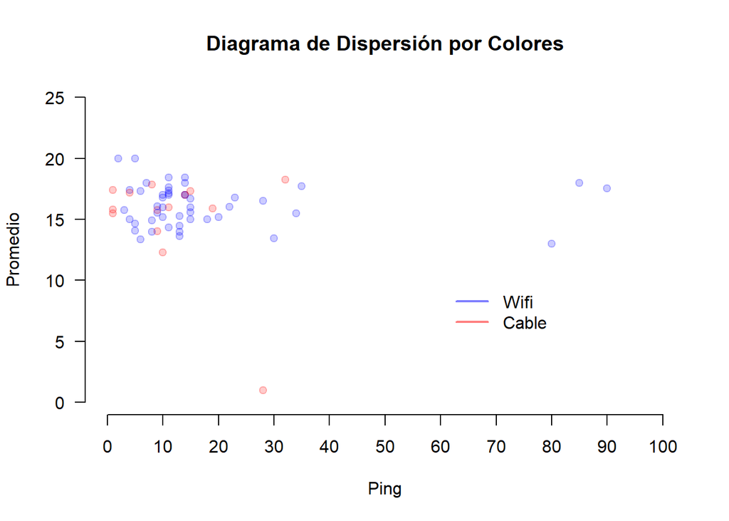

## Regresión Lineal (Mínimos Cuadrados)

**1. “Calidad de Internet” - Promedio**

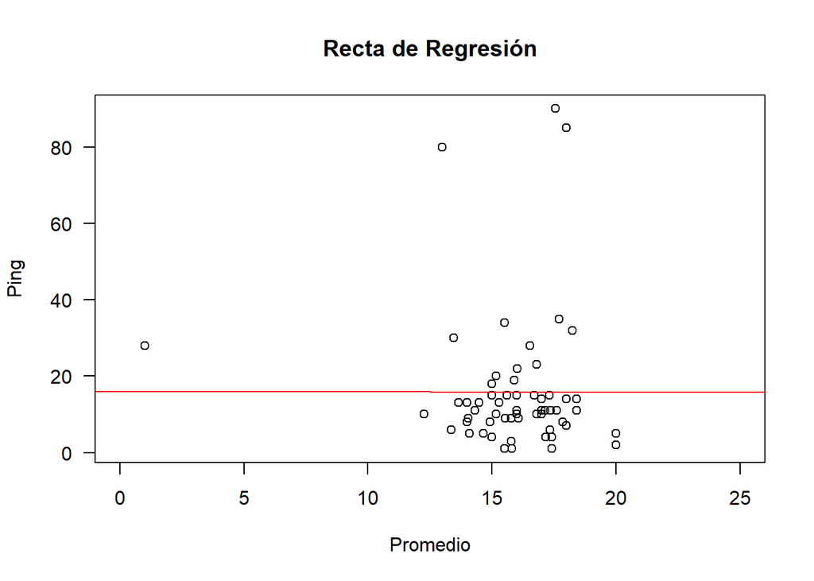

- **Fórmula:**
  $$f(x) =
  -0.008762x + 16.044117$$

**2. Convivientes - Equipos_Conectados**

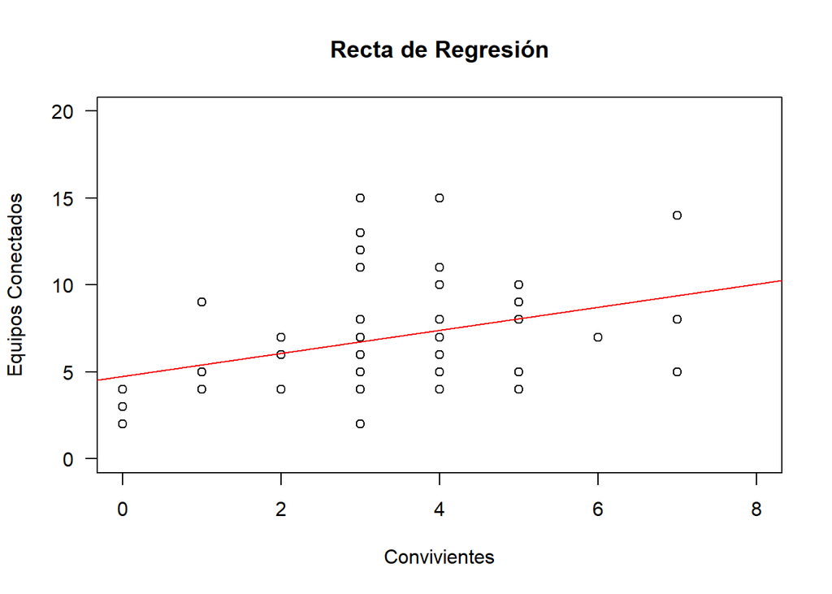

- **Fórmula:**
  $$f(x) =
  0.6627 + 4.7536$$

# **Análisis probabilístico**

## Descripción probabilística

### Univariado

**Inasistencias:** La inasistencia por problemas de internet es relevante, ya que nos indica qué porcentaje de alumnos es perjudicado **directamente** por una baja calidad de conexión. Como se observa en el siguiente gráfico, concluimos que existe una probabilidad del **86.89%** de que un alumno haya tenido al menos una inasistencia por los motivos descritos.

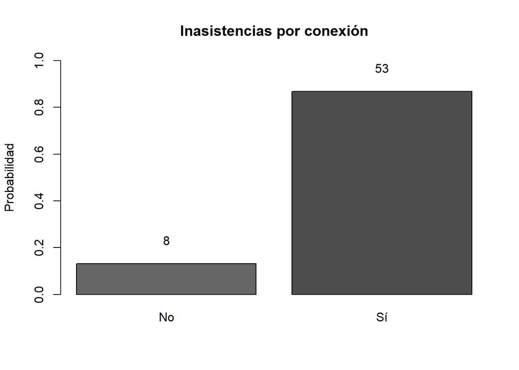

**Peor Conectividad:** Es también relevante qué período del día ofrece la peor conexión del día, a manera de advertencia y preparación. Los siguientes datos nos indican qué tan probable es presentar más complicaciones o tener **más fallas conectivas de lo común**. Vemos que la probabilidad de tener caídas de internet u otras dificultades en la tarde (de 1-5 pm) es **casi 50%**.

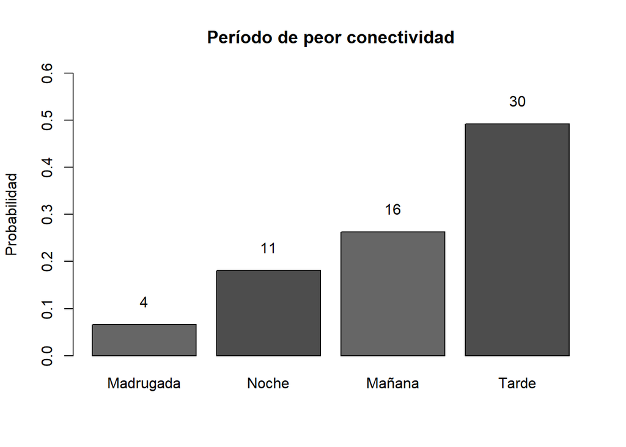

**Alternativa:** Es importante conocer si se poseen alternativas de conexión en casos de emergencia, ya que estas enmendan los casos de inasistencias o pruebas perdidas. Como vemos a continuación, existe un **80.33%** de probabilidad de que un alumno posea una alternativa en caso de fallo de internet; por lo que hay aún un **19.67%** de que no haya forma de solucionar el problema.

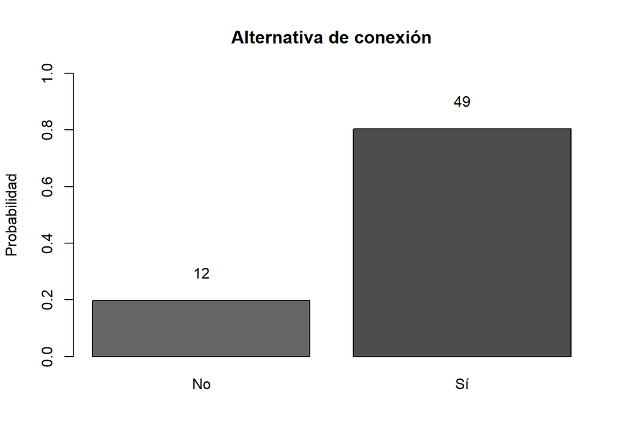

**Pruebas Perdidas:** Al igual que las inasistencias, las pruebas perdidas por una pobre calidad de internet, son también perjudiciales, incluso más que la variable anterior. Por lo tanto, en el siguiente gráfico podemos comprobar que la probabilidad de perder como mínimo 1 prueba es más del 65% y que la cantidad esperada es **1.52 o 2** (redondeando) pruebas perdidas.

[figure not shown]

### Bivariado

**Inasistencia - Ping:** Sabiendo que **Ping** es una variable que nos indica qué tan lenta es la conexión y que por lo tanto es inversamente proporcional a una buena calidad de internet, podemos plantear una hipótesis inicial en base a estas dos variables: Si un alumno ha tenido **una o más inasistencias** es más probable que tenga un **ping alto**, mientras que si no ha tenido **ninguna inasistencia** es más probable que tenga un **ping bajo**. Gracias a la esperanza, podemos ver el valor esperado en cada caso y **comprobamos la hipótesis** de probabilidad condicional.

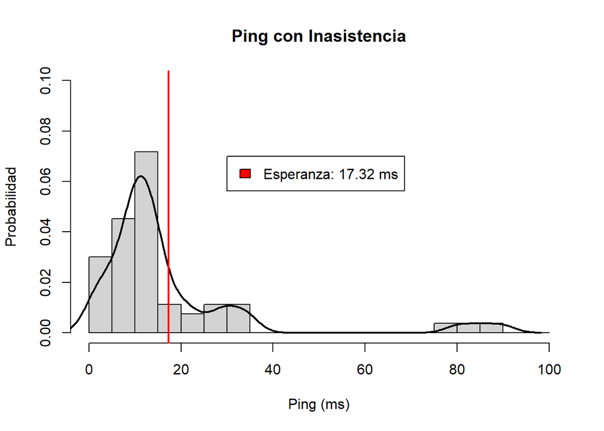

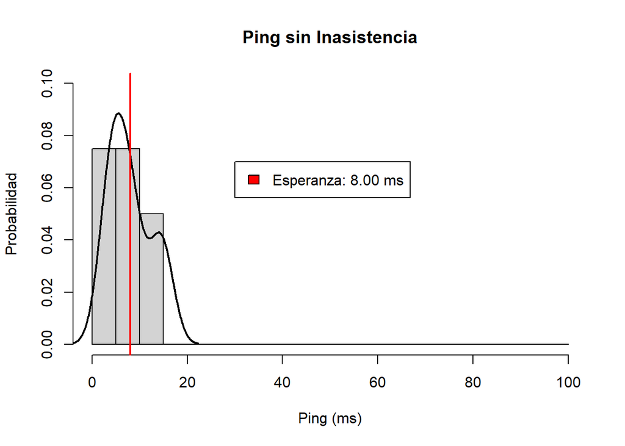

**Inasistencia - Download:** Al igual que en la relación anterior, debemos determinar que **Download** es una variable que nos indica la rapidez de descarga de la conexión, siendo directamente proporcional a una buena calidad de internet. Por lo tanto, podemos plantear una nueva hipótesis: Si un alumno no ha tenido **ninguna inasistencia**, es más probable que tenga un **download alto**, mientras que si ha tenido **una o más inasistencias** es más probable que tenga un **download bajo**. En base a la esperanza, **concluimos que la hipótesis está errada** y descartamos la probabilidad condicional estipulada.

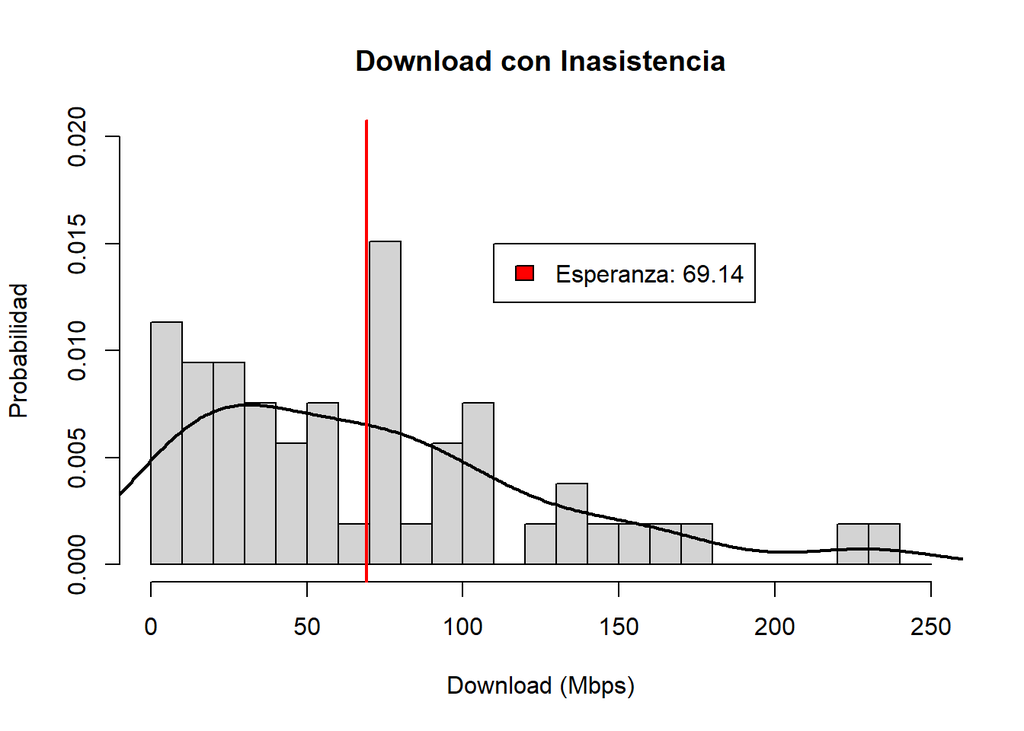

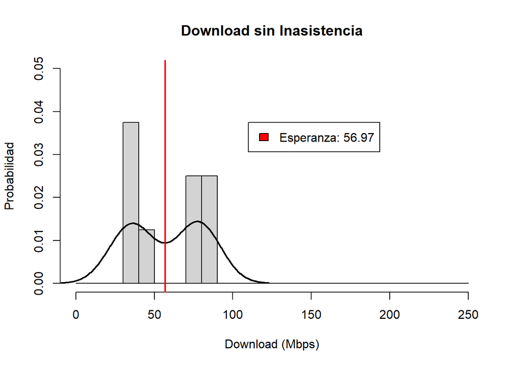

# Distribuciones Discretas

**1. Peor_Conectividad - Hipergeométrica**

| Peor_Conectividad | n |
| --- | --- |
| Tarde | 30 |
| Mañana | 16 |
| Noche | 11 |
| Madrugada | 4 |

Distribución Discreta Hipergeométrica que cuenta *individuos con una determinada característica* en una **Muestra** $n$ obtenida de una **Población** $N$ con $r$ *individuos que poseen dicha característica*.

$$X\sim\mathsf{Hiper}(61, 30,
10)$$

Hay que destacar que **NO** es acertado pensar que la Variable `Peor_Conectividad` se modela como Binomial. Esto debido a que la probabilidad de éxito está cambiando con cada ensayo Bernoulli sin reemplazo que realizamos. En la Distribución Hipergeométrica, las probabilidades de éxito van a ir cambiando debido a que **los eventos no son independientes**

Nuestra muestra ahora es la Variable `DF$Peor_Conectividad`. De ella estamos sacando una Muestra más pequeña. Por lo tanto, tenemos una Variable Aleatoria X que se modela Hipergeométricamente con los siguientes parámetros

- N = 61
- r = 30
- n = 10

Tenemos una Población de 61 individuos, en la cual, *hay 30 que experimentan la peor conectividad a internet en la Tarde*. Si de la población retiramos 10 individuos:

1. ¿Cuál es la probabilidad de que 5 de ellos experimenten la peor conectividad a internet en la Tarde?

$$\mathbb{P}(x = 5)$$

```
## [1] 0.2685085
```

2. ¿Cuál es la probabilidad de que a lo mucho 5 de ellos experimenten la peor conectividad a internet en la Tarde?

$$\mathbb{P}(x <= 5)$$

```
## [1] 0.6559082
```

[output not shown]

# Distribuciones Continuas

**1. Download - Uniforme**

DISTRIBUCIÓN HIPOTÉTICA:

X ~ U(alfa, beta) alfa = 120 beta = 175

COMPARAR HISTOGRAMA Y FUNCIONES DE DENSIDAD:

$$f(x) = 1 / alfa - beta$$

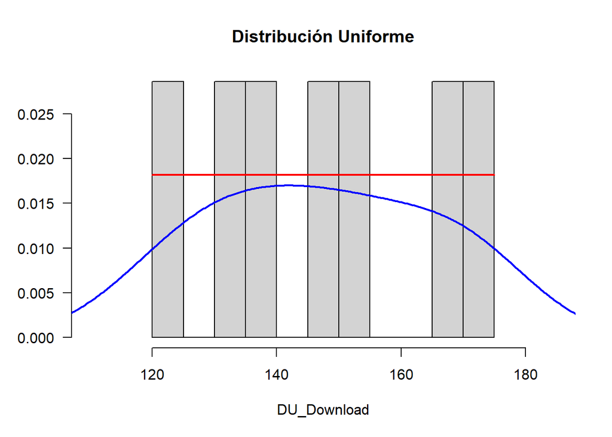

COMPARAR PARÁMETROS TEÓRICOS Y REALES:

$$E(X) = mu = (alfa + beta) /
2$$

$$Varianza = sigma^2 = (beta - alfa) /
12$$

Vemos que, sorprendentemente, las Esperanzas Teórica y Real son muy idénticas. Sin embargo, la comparación entre las Varianzas nos lleva a concluir que, así como no es suficiente tener un Histograma que se asemeje a alguna Distribución, tampoco basta con que ambas Esperanzas resulten parecidas. Hay que comparar todos los parámetros y resultados de la Distribución hipotética con los valores reales para tomar una decisión, incluyendo la Varianza.

```
## Esperanza_Teórica    Esperanza_Real  Varianza_Teórica     Varianza_Real
##            147.50            147.20              4.58            336.43
```

Probabilidad de que la Variable Aleatoria X `DU_Download` alcance a lo mucho 142 de Download

```r
punif(142, min = 120, max = 175)
```

```
## [1] 0.4
```

2. Promedio - Normal

El histograma sugiere ser continua, sin embargo, el tipo de variable lo desmiente dado que la variable promedio toma valores en un rango contable (variable discreta)

**Variable Discretizada** **La variable promedio por naturaleza es continua**

```
## [1] 12.27 20.00
```

DISTRIBUCIÓN HIPOTÉTICA

X ~ N(mu, sigma) mu = 16.15 sd = 1.65

COMPARAR HISTOGRAMA Y FUNCIONES DE DENSIDAD

$$f(x) = (1 / sqrt(2 * pi) * sd) * e ^
-((x - mu)^2 / (2var))$$

Vemos que la Función de Densidad Teórica de la Distribución Hipotética Continua se asemeja bastante a la Función de Densidad Real, comando `density()` de la variable. No obstante ninguna de las dos explican correctamente la distribución real de la Variable `DN_Promedio`. Esto se concluye al analizar la gráfica con los parámetros `break` y `ylim` del comando `hist()`.

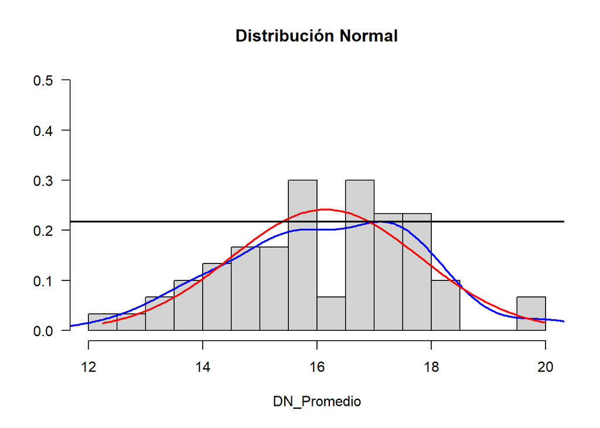

COMPARAR PARÁMETROS TEÓRICOS Y REALES

La Función de Densidad $f(x)$ tiene un máximo en x = mu y está dado por la siguiente fórmula:

$$f(mu) = 1/(sd * sqrt(2 *
pi))$$

Para hallar $f(mu)$ Real, utilizamos el siguiente código. Sabemos por teoría que, para una Distribución Continua Normal, el valor de $mu$ coincide con el punto más alto de la gráfica. Asimismo, la distribución debe ser simétrica alrededor de $mu$. No obstante, dado que vemos en la Función de Densidad Real, con `density()`, **dos “máximos locales”**, siendo el mayor el más alejado del centro, concluimos que la distribución de la variable `DN_Promedio` NO se distribuye Normal. Es más, por más que ambos valores se asemejen, f(mu) Real ≅ f(mu) Teórico, el mu Real no termina de satisfacer la característica de un mu Teórico, la cual es ser el **centro donde la variable se distribuye simétricamente**.

```r
mu = 16.15
sd = 1.65

# f(mu) Teórico
r(1/(sd * sqrt(2 * pi)))
```

```
## [1] 0.24
```

```r
# f(mu) Teórico  = 0.24
# f(mu) Real  = 0.2170980
```

Probabilidad de que la Variable Aleatoria X `DN_Promedio` alcance por lo menos 16 de promedio

```r
pnorm(16, 16.15, 1.65, lower.tail = F)
```

```
## [1] 0.5362176
```